# Sissejuhatus R-i ja RStudiosse

Indrek Soidla

2024-09-04

Laeme sisse tööks vajalikud paketid ja andmed. Kasutame täna sama projekti ja sama andmestikku, mida eelmistelgi kordadel. Meeldetuletus: juba installeeritud pakette pole vaja enam installeerida, küll aga on tarvis nad uue sessiooni alguses (st R-i taaskäivitades) sisse laadida.

```r
library(tidyverse)

pfi <- read.csv2("data/rsf_2022.csv")
```

Eelmine kord käsitlesime erinevaid paketi `dplyr` funktsioone, mis aitavad andmestikust ülevaate saada:

- `arrange`
- `select`
- `pull`
- `filter`

Tutvume täna veel mõnede `dplyr`’i funktsioonidega, sest `dplyr` on tõhus tööriistakast andmestikega (R-i mõistes *data frame*’idega) töötamiseks. `dplyr`’i pakett on osa `tidyverse`’i pakettide kogumist. `dplyr`’i funktsioonid eeldavad alati sisendiks *data frame*’i (mitte nt vektorit või muud tüüpi andmehulka) ja annavad väljundiks alati *data frame*’i.

## Tunnuste ümberkodeerimine, uute tunnuste loomine

Kuidas saada ülevaade regiooni tunnusest? Vaatame `dplyr`’i funktsiooniga `distinct`, millised erinevad regioonid on esindatud, st millistesse regioonidesse on riigid andmestikus jaotatud.

```r
pfi %>%
  distinct(zone)
```

```
##             zone
## 1 Asie-Pacifique
## 2     UE Balkans
## 3           MENA
## 4        Afrique
## 5      Amériques
## 6           EEAC
```

Näeme, et esineb kuus erinevat regiooni. Samas ei näe me, kui palju mingi regiooni all riike on. Seda näeme nt funktsiooniga count, kus esimene argument on andmestik ja teine tunnus, mille väärtusi kokku loendame.

```r
pfi %>%
  count(zone)
```

```
##             zone  n
## 1        Afrique 48
## 2      Amériques 28
## 3 Asie-Pacifique 32
## 4           EEAC 13
## 5           MENA 19
## 6     UE Balkans 40
```

Näeme, et kõige rohkem riike on Aafrika regioonis (48). Paraku on pressivabaduse indeksi andmestikus aga regioonide nimetused prantsuse keeles, osad neist on veidi krüptilise lühendiga. Võiksime need asendada eestikeelsetega, et edasine andmetöötlus oleks selgem, ehk võiksime tunnuse väärtused ümber kodeerida.

Uurime, millised riigid millises regioonis esinevad (sorteerime andmestiku regiooni tunnuse järgi) ja kodeerime tunnuse ümber, st anname regioonidele eestikeelsed nimetused. Sorteerimise saab teha järgneva käsuga:

```r
pfi %>%
  select(zone, country) %>%
  arrange(zone)
```

Väljundist (pikkuse tõttu pole siinkohal esitatud) saame järeldada, et *EEAC* tähistab Ida-Euroopat ja Kesk-Aasiat ning *MENA* Lähis-Ida ja Põhja-Aafrikat, *UE Balkans* peaks tähendama EL-i ja Balkani riike, kuigi seal esinevad ka nt Norra ja Šveits. Anname regiooni tunnuse kategooriatele selgemad nimed. Tunnuse `zone` ümberkodeerimiseks kasutame `dplyr`i funktsiooni `case_match`, kus esimeseks argumendiks on ümberkodeeritava tunnuse nimi ja järgmistes argumentides vanad ja uued väärtused, mis on kokku viidud tildega (`~`). See võimaldab seadistada n-ö ümberkodeerimise skeemi, uue tunnuse `regioon` loomiseks on tarvis kasutada funktsiooni `mutate`. Et ümberkodeerimise tulemus (uus tunnus) talletuks, omistame käsu tulemuse (andmestiku, kus on uus tunnus) tagasi objektile `pfi`.

```r
pfi <- pfi %>%
  mutate(regioon = case_match(zone,
                          "Afrique" ~ "Aafrika",
                          "Amériques" ~ "Põhja- ja Lõuna-Ameerika",
                          "Asie-Pacifique" ~ "Aasia & Okeaania",
                          "EEAC" ~ "Ida-Euroopa & Kesk-Aasia",
                          "MENA" ~ "Lähis-Ida & Põhja-Aafrika",
                          "UE Balkans" ~ "EL & Balkan"))
```

Kontrollige, kas andmestikku tekkis uus tunnus, nt võite proovida käske `names(pfi)` või `head(pfi)` – esimesel juhul esitatakse konsoolis andmestikus olevate tunnuste nimed, mille hulgas peaks olema ka `regioon`, teisel juhul esitatakse andmestiku kuus esimest rida, kus viimases veerus on ka tunnus regioon.

Kontrollime veel, kas kodeerimine sai õigesti tehtud.

```r
pfi %>%
  count(zone, regioon)
```

```
##             zone                   regioon  n
## 1        Afrique                   Aafrika 48
## 2      Amériques  Põhja- ja Lõuna-Ameerika 28
## 3 Asie-Pacifique          Aasia & Okeaania 32
## 4           EEAC  Ida-Euroopa & Kesk-Aasia 13
## 5           MENA Lähis-Ida & Põhja-Aafrika 19
## 6     UE Balkans               EL & Balkan 40
```

Mul sai küll – väljundtabelis vastavad prantsuskeelsed nimed eestikeelsetele ja iga nimi esineb ainult ühel real nagu ümberkodeerimiseeskiri `case_match` käsus ette nägi.

Eelnevas näites kodeerisime ümber kategoriaalset tunnust – sellisel juhul on erinevate väärtuste arv tunnuses väike. Arvulise tunnuse puhul läheks iga erineva väärtuse kirjapanek liiga pikaks, siis on mõttekas kasutada väärtuste vahemikel põhinevaid loogilisi tingimusi nagu eelnevalt filtreerimise puhul. Proovimegi ümberkodeerimist arvulise tunnuse põhjal. Teeme uue kategoriaalse tunnuse `koondindeks_kat`, milles liigitame riigid vastavalt nende koondindeksi skoori järgi kategooriatesse, kus pressivabaduse olukord on järgmine:

- vähemalt 85: hea
- vähemalt 70, alla 85: rahuldav,
- vähemalt 55, alla 70: problemaatiline,
- vähemalt 40, alla 55: keeruline
- alla 40: väga tõsine

Et kirja panna arvulistel vahemikel põhinevaid tingimusi, on tarvis funktsiooni `case_match` asemel kasutada funktsiooni `case_when` (samuti paketist `dplyr`, mis on osa `tidyverse`’ist). Et uue tunnusega andmestik salvestuks (mitte ei esitataks konsoolis), on tarvis ümberkodeerimise tulemus objektile omistada (noolega `<-`).

```r
pfi <- pfi %>%
  mutate(koondindeks_kat = case_when(global_score >= 85 ~ "Hea",
                                     global_score >= 70 ~ "Rahuldav",
                                     global_score >= 55 ~ "Problemaatiline",
                                     global_score >= 40 ~ "Keeruline",
                                     global_score < 40 ~ "Väga tõsine"))
```

Nagu eelnevast koodijupist näha, ei ole meil kolme keskmise kategooria puhul vaja ette anda kategooriate ülemisi piire (nt rahuldava kategooria puhul pole vaja täpsustada `global_score >= 70 & global_score < 85`), kuna need on arvesse võetud juba eelneva kategooria tingimusega. Teisiti öeldes, need riigid, mille puhul indeksi skoor on vähemalt 85, on juba eelneva tingimusega n-ö reserveeritud kategooria “Hea” jaoks.

Võite kontrollida ka, kas ümberkodeerimine õnnestus:

```r
pfi %>%
  select(global_score, koondindeks_kat) %>%
  arrange(global_score)
```

```
##     global_score koondindeks_kat
## 1          13.92     Väga tõsine
## 2          19.62     Väga tõsine
## 3          23.22     Väga tõsine
## 4          25.01     Väga tõsine
## 5          25.03     Väga tõsine
## 6          25.17     Väga tõsine
## 7          26.11     Väga tõsine
## 8          27.32     Väga tõsine
## 9          28.59     Väga tõsine
## 10         28.94     Väga tõsine
## 11         28.98     Väga tõsine
## 12         29.14     Väga tõsine
## 13         30.23     Väga tõsine
## 14         30.97     Väga tõsine
```

[output cut: 166 more lines]

### Harjutus 1

#### Ülesanne

Selle koodiga luuakse allolev joonis. Tehke koodis vajalikud täiendused, et joonis oleks täielikult eestikeelne, lisage joonisele ka pealkiri.

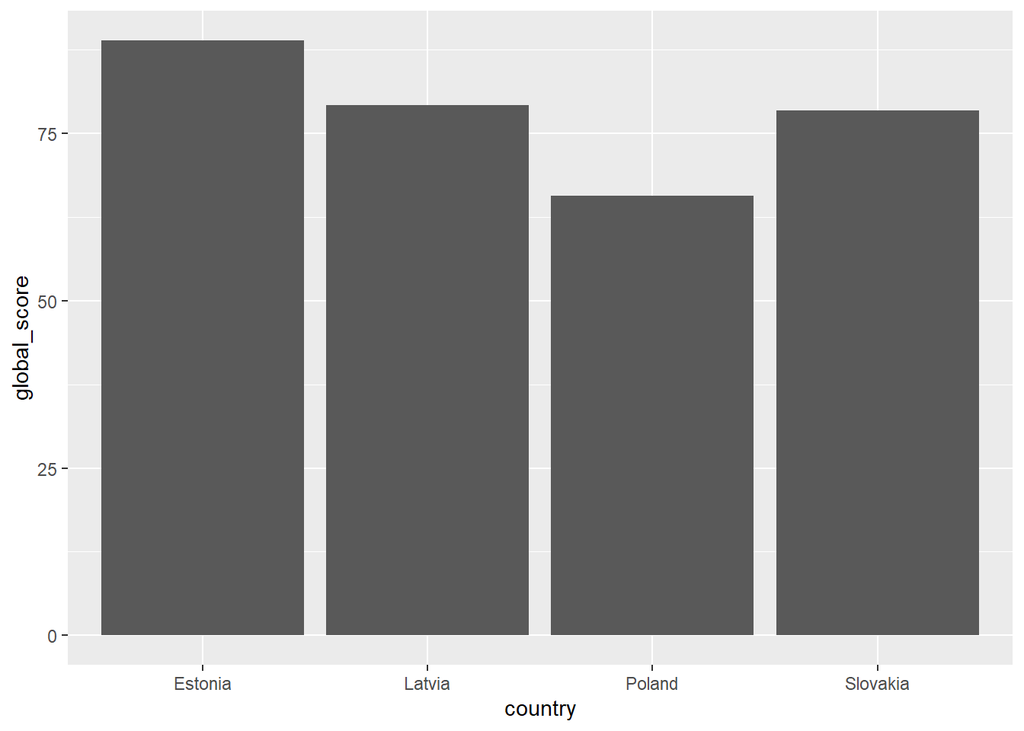

```r
pfi %>%
  filter(country %in% c("Estonia", "Latvia", "Poland", "Slovakia")) %>%
  ggplot(aes(y = global_score, x = country)) +
  geom_col()
```

#### Vihje

Riikide nimed tuleks ümber kodeerida eestikeelseteks. Olemasoleva tunnuse muutmiseks saab kasutada funktsiooni `mutate`, selle käsu raames tunnuse ümber kodeerimiseks on võimalik kasutada nii funktsiooni `case_match` kui `case_when`, aga tulenevalt tunnuse tüübist on antud juhul üks neist lihtsam kui teine.

Telgede nimede eestikeelseks muutmiseks on tarvis kasutada ühte `ggplot`’iga seotud funktsiooni, mille leiate esimese praktikumi õppematerjalist harjutuse 1 koodist, kus loodi joonis ÜRO hääletuste andmete põhjal.

#### Tulemus

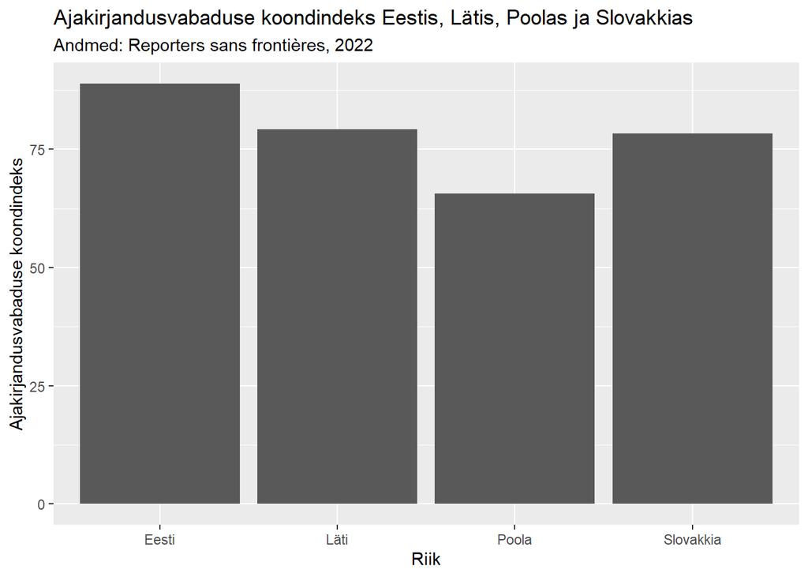

### Harjutus 2

#### Ülesanne

Looge andmestikku tunnuse `diff_2021` alusel uus tunnus `diff_2021_kat` järgmise skeemi alusel:

- `diff_2021` väärtus madalam kui -10 = pressivabaduse olukord palju halvem
- `diff_2021` väärtus -10 kuni -3 = pressivabaduse olukord halvem
- `diff_2021` väärtus -2 kuni 2 = pressivabaduse olukord ligikaudu sama
- `diff_2021` väärtus 3 kuni 10 = pressivabaduse olukord parem
- `diff_2021` väärtus kõrgem kui 10 = pressivabaduse olukord palju parem

Leidke, kuidas Lähis-Ida ja Põhja-Aafrika riigid nende kategooriate vahel jagunevad. Teisiti sõnastades, kui paljudes selle regiooni riikides on pressivabaduse olukord võrreldes varasema aastaga muutunud palju halvemaks, halvemaks, jäänud enam-vähem samaks jne?

#### Vihje

Uue tunnuse loomiseks kasutage funktsiooni `mutate`. Millist `case_*` funktsiooni on tarvis kasutada arvulise tunnuse ümberkodeerimiseks?

#### Vihje

Vastuseks on vaja leida ümberkodeeritud tunnuse jaotus Lähis-Ida ja Põhja-Aafrika regioonis. Seega on tarvis kõigepealt andmestikku filtreerida (tunnuse `regioon` või `zone` alusel) ja seejärel arvutada jaotus. Selleks saab kasutada `dplyr`’i funktsiooni `count`.

#### Tulemus

Pärast ümberkodeerimist saab funktsiooniga `count` sellise väljundi:

```
##    diff_2021_kat n
## 1         Halvem 3
## 2 Ligikaudu sama 6
## 3   Palju halvem 5
## 4    Palju parem 2
## 5          Parem 3
```

Tunnuse `diff_2021_kat` väärtused on tekstilised, seetõttu esitatakse jaotustabelis kategooriate sagedused vaikeseadena tähestikulises, mitte skaala loogilises järjekorras või sageduse järjekorras. See pole sisuliselt kuigi ülevaatlik. Tunnus on sisuliselt küll kategoriaalne, kuid mitte R-i mõistes – R-i mõistes on tegu lihtsalt tekstiliste väärtustega tunnusega. Tunnuse väärtuseid või kategooriaid saab järjestada, muutes tunnuse tüübi R-i mõistes kategoriaalseks ehk `factor`’iks (ehk faktortunnuseks) ja defineerides samas käsus ka kategooriate järjekorra.

```r
pfi <- pfi %>%
  mutate(diff_2021_kat = factor(diff_2021_kat,
                                levels = c("Palju halvem", "Halvem", "Ligikaudu sama", "Parem", "Palju parem")))
```

Kui loote nüüd sama tabeli uuesti, on tunnuse `diff_2021_kat` kategooriad loogilises järjestuses.

```
##    diff_2021_kat n
## 1   Palju halvem 5
## 2         Halvem 3
## 3 Ligikaudu sama 6
## 4          Parem 3
## 5    Palju parem 2
```

### Harjutus 3

#### Ülesanne

Alustame tasapisi ka andmete visualiseerimisega. Vaadake harjutuses 1 olevat koodi, millega luuakse tulpdiagramm. Proovige harjutuses 2 saadud tabel esitada samuti tulpdiagrammil.

#### Vihje

Üks võimalus selline tulpdiagramm luua on sööta harjutuses 2 saadud tabel `%>%`-ga edasi funktsioonile `ggplot`, teine võimalus on harjutuse 2 tabel omistada uuele objektile ja kasutada seda objekti funktsiooni `ggplot` argumendis `data`. Edasi tuleb `ggplot`-käsus defineerida, millised harjutues 2 saadud tabeli veerud esitatakse x- ja y-teljel ning järgmisel real kasutada funktsiooni `geom_col`, millega seadistatakse joonisel andmete esitamine tulpdiagrammi kujul. Funktsiooniga `labs` saab seadistada telgede nimed ja pealkirja.

#### Tulemus

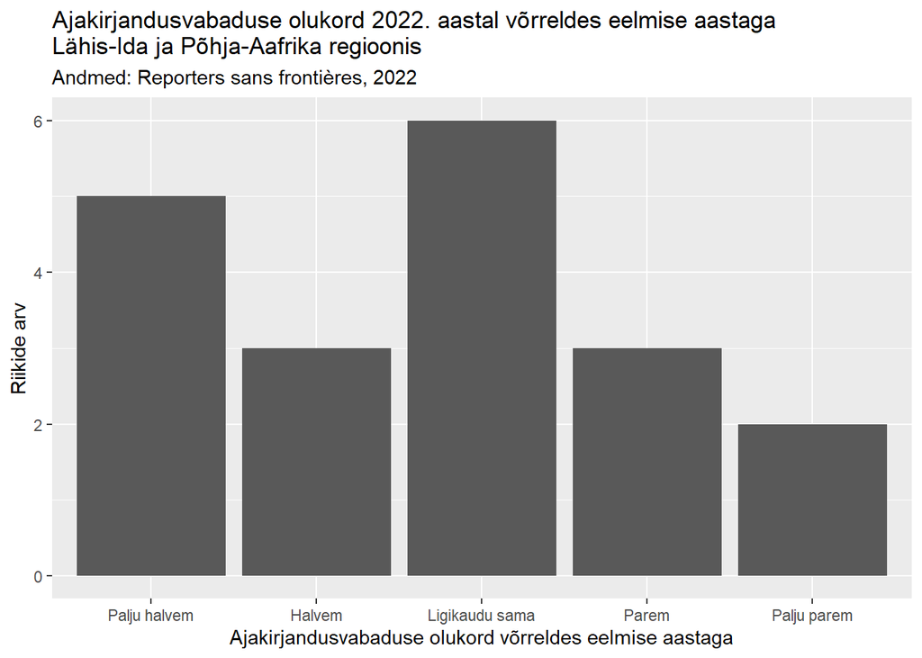

## Uute tunnuste loomine arvutuste põhjal

Vaatame nüüd, kuidas muutus ajakirjandusvabaduse olukord mitte ainult Lähis-Ida ja Põhja-Aafrika regioonis, vaid kogu maailmas.

```r
pfi %>%
  count(diff_2021_kat)
```

```
##    diff_2021_kat  n
## 1   Palju halvem 43
## 2         Halvem 34
## 3 Ligikaudu sama 28
## 4          Parem 27
## 5    Palju parem 48
```

Saime riikide absoluutse jaotuse ehk riikide arvud, aga ülevaatlikum oleks protsentjaotus. Selle jaoks saame eelnevaga sarnaselt kasutada funktsiooni `mutate`, luues saadud tabelisse ka protsentjaotuse veeru. Võime tabeli salvestada, et edaspidi oleks vaja vähem koodi kirjutada.

```r
diff_tbl <- pfi %>%
  count(diff_2021_kat)

diff_tbl %>%
  mutate(perc = n / sum(n))
```

```
##    diff_2021_kat  n      perc
## 1   Palju halvem 43 0.2388889
## 2         Halvem 34 0.1888889
## 3 Ligikaudu sama 28 0.1555556
## 4          Parem 27 0.1500000
## 5    Palju parem 48 0.2666667
```

Ülevaatlikum oleks protsendid esitada täisarvu kujul ja kasutada ka ümardust.

```r
diff_tbl %>%
  mutate(perc = n / sum(n) * 100,
         perc = round(perc, 0))
```

```
##    diff_2021_kat  n perc
## 1   Palju halvem 43   24
## 2         Halvem 34   19
## 3 Ligikaudu sama 28   16
## 4          Parem 27   15
## 5    Palju parem 48   27
```

Tabeli põhjal näeme, et riike, kelle positsioon on paranenud, on enam-vähem sama palju kui neid, kelle positsioon halvenenud. Mida selle põhjal saaks sisuliselt järeldada?

### Harjutus 4

#### Ülesanne

Ütleme, et meid huvitab eelkõige ajakirjandusvabadus poliitilise ja majandusliku ja juriidilise konteksti alusel. Saaksime riike üksikasjalikumalt võrrelda iga nende kolme alusel, samas ülevaatlikum oleks arvutada nende kolme mõõtme alusel üks indeks. Arvutage andmestikku `pfi` tunnus `pol_ec_leg_score`, milles oleks iga riigi kohta poliitilise, majandusliku ja juriidilise mõõtme aritmeetiline keskmine.

#### Vihje

Saate selleks kasutada funktsiooni `mutate`. Kuna aritmeetilised keskmised tuleb arvutada ainult kolme tunnuse põhjal, on antud hetkel kõige lihtsam kasutada arvutustehet `(tunnus1 + tunnus2 + tunnus3) / 3`.

#### Tulemus

Ruumi kokkuhoiu mõttes esitan siin uue tunnusega andmestikust ainult kümme esimest rida.

```r
head(pfi, n = 10)
```

```
##    rank     country global_score political_context economic_context
## 1   156 Afghanistan        38.27             44.65            43.88
## 2   103     Albania        56.41             50.55            29.39
## 3   134     Algeria        45.53             41.21            32.40
## 4    53     Andorra        68.79             68.12            50.41
## 5    99      Angola        57.17             52.83            35.03
## 6    29   Argentina        77.28             76.36            51.53
## 7    51     Armenia        68.97             66.26            44.44
## 8   154  Azerbaijan        39.40             37.66            23.76
## 9    39   Australia        73.77             77.17            63.44
## 10   31     Austria        76.74             77.82            61.43
##    legal_framework sociocult_context safety diff_2021           zone
## 1            42.54             43.33  16.96       -34 Asie-Pacifique
## 2            68.77             66.60  66.75       -20     UE Balkans
## 3            54.17             55.88  44.02        12           MENA
```

[output cut: 18 more lines]

### Harjutus 5

#### Ülesanne

Kuivõrd on saadud indeks seotud sotsiokultuurilise konteksti ja ohutuse mõõtmetega, st kas riigid erinevad saadud indeksi ja kahe ülejäänud mõõtme alusel oluliselt või mõõdavad need konstruktid enam-vähem sarnaseid nähtuseid? Proovime jälle andmeid visualiseerida. Koostage kaks punktdiagrammi, kus ühel on vastloodud indeksi ja sotsiokultuurilise konteksti andmed, teisel diagrammil indeksi ja ajakirjanike ohutuse andmed. Kumb on meie loodud indeksiga tugevamalt seotud, kas ajakirjandusvabadus sotsiokultuurilise mõõtme alusel või ajakirjanike ohutus?

#### Vihje

Antud jooniste koostamise loogika on sarnane eelnevalt tehtud joonistega. Eelnevatest joonistest erinev on see (lisaks esitatavatele tunnustele), et esitame andmed punktidena, mitte tulpadena. Selle jaoks saab kasutada funktsiooni `geom_col` asemel funktsiooni `geom_point`.

#### Tulemus

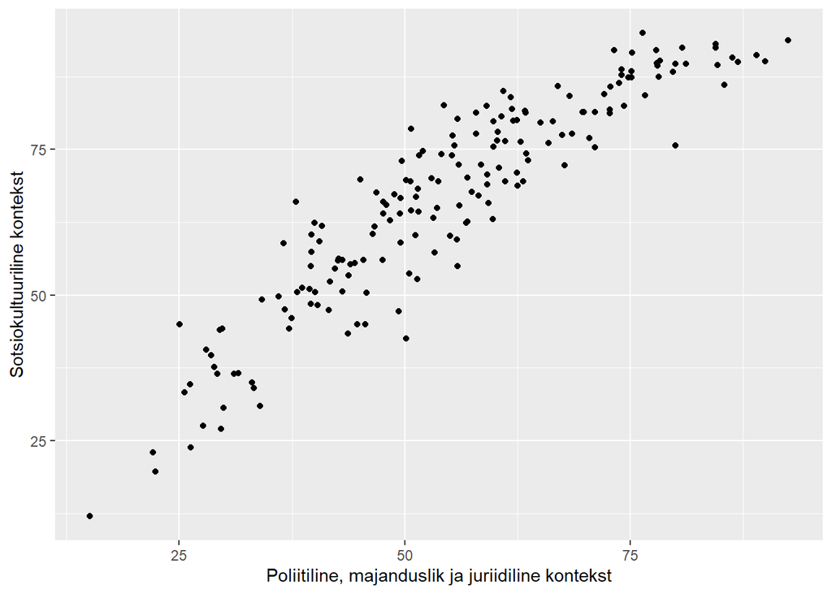

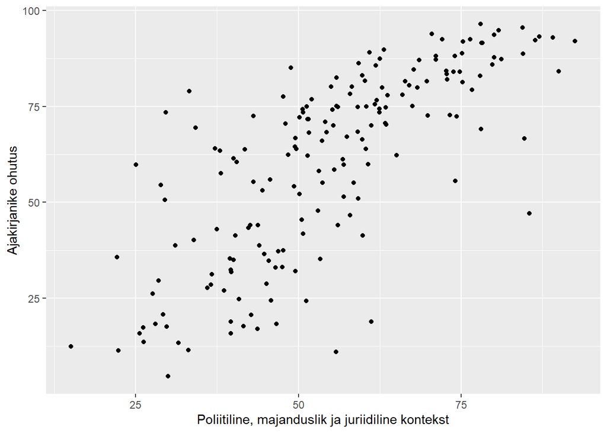

### Harjutus 6

#### Ülesanne

Muutke eelnevas harjutuses saadud punktdiagramme nii, et värvi alusel oleks eristatavad eri regioonide riigid. Võite uurida, kuidas seda on tehtud esimese praktikumi harjutuses 1. Milliseid seaduspärasid joonistelt märkate?

#### Vihje

See, milliste visuaalsete parameetritega tunnusete väärtuseid joonisel esitatakse (kas nt asukoha või värvi alusel), seadistatakse `ggplot`-käsus argumendiga `mapping`, funktsiooni `aes` (ehk *aesthetics*) abil.

#### Tulemus

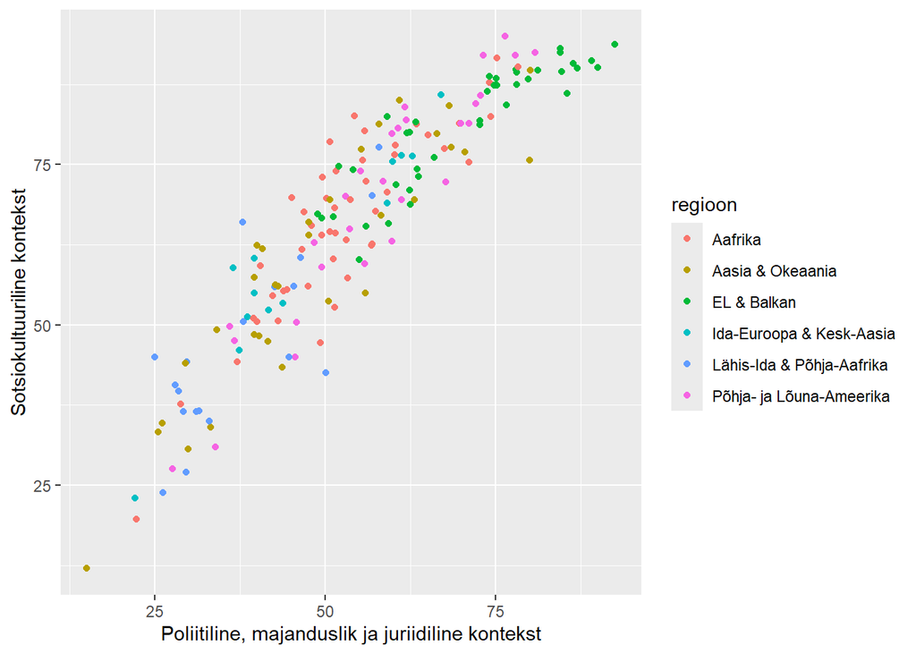

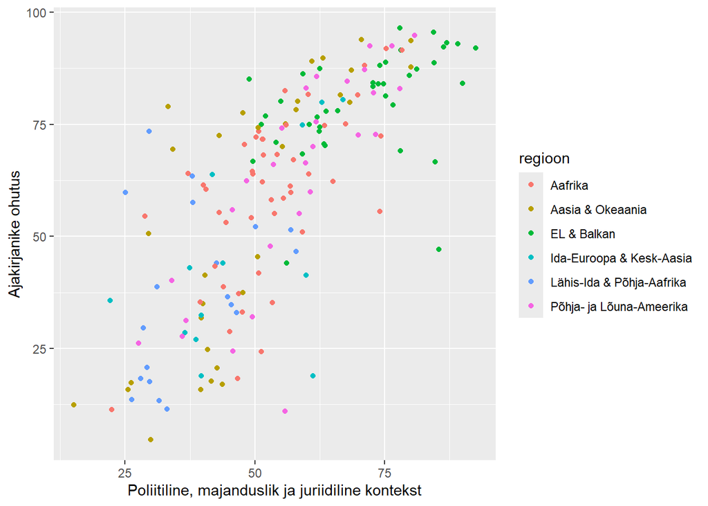